# Aside

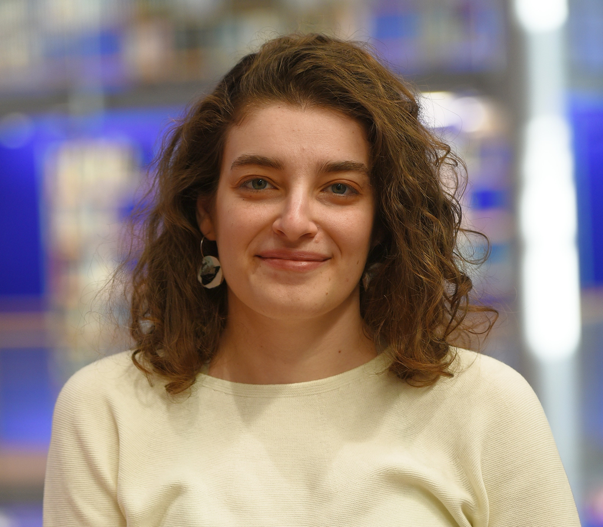

[See the html of this CV](https://selkubi.github.io/cv.html)

## About Me

- Portuguese, Turkish
- English, French, German (B1), Turkish
- kubilay.selin@gmail.com
- Selkubi
- [Selin Kubilay](https://www.linkedin.com/in/selin-kubilay-b19335149/)
- [Code Sample from Portfolio](https://github.com/Selkubi/Cantabria-Paper-Data-Analysis-and-Visualisations)

## Programming Skills

ggplot2

Markdown

R data.table

R tidyverse

Git/Github

R shiny

Python

Latex

Bash

SQL

## Technical SKILLS

Dashboards

R package development

Docker

CI/CD

AWS

# Main

## Selin Kubilay

With a background in aquatic sciences, I transitioned into **research data management**, following my passion for FAIR research software development and open science advocacy. I thrive in interdisciplinary environments and particularly enjoy developing **R packages** and **interactive dashboards** that enhance data accessibility and usability. In my free time, I enjoy hiking, road biking, bouldering, and hosting board game nights.

## Employment History

### Research Data Manager

Delft

Delft University of Technology

Current - 2023

- Co-developed data engineering and analysis solutions in R and Python for research projects
- Designed and implemented relational and non-relational database solutions
- Contributed to the library trainings targeted to researchers for establishing good software development practices
- Organized [R cafe](https://delft-rcafe.github.io/home/about.html) meetings to establish an R community in TU Delft
- Participated in several workshops for adopting better research software practices

### Guest Researcher

Innsbruck

University of Innsbruck

2022 - 2020

- Built a groundwater experiment as part of doctoral research to assess the influence of carbon regime disturbances on microbial carbon utilization
- Used R with STAN to analyze and interpret the complex experimental design with a Bayesian model
- Helped build a new lab from scratch for the research group [FLEE](https://www.uibk.ac.at/de/ecology/forschung/fluvial-ecosystem/)

### Researcher

Berlin

Leibniz Institute of Freshwater Ecology and Inland Fisheries

2022 - 2018

- Investigated the impacts of dam-related flow regime disruptions on riverine biogeochemical interactions through spatio-temporal analysis of dissolved organic carbon data
- Campaigned for groundwater sampling excursions for Trace Organic Chemical Research
- Presented in SoapboxScience events for public outreach
- Participated in several conferences with posters or presentations for dissemination of research results

### Research Intern

Copenhagen

University of Copenhagen

2017

- Analysed and visualised data in R for a soil remediation project
- Obtained funding through the Excellency Scholarship from TUBITAK for my stay in Cophenagen

## Education

Relevant Trainings

##### 2025

- **Carpentries Instructor Training** *(The Carpentries)*

##### 2024

- **Data Modeling and Relational Data Architecture** *(EssentialSQL)*
- **Good Practices in Research Software Development** *(Netherlands eScience Center)*

##### 2023

- **Reproducible Research with R Packages** *(Netherlands eScience Center)*

##### 2021

- **Model-Data Integration for Natural Sciences: Non-parametric modeling with artificial neural networks and applied deep learning with R and Python** *(University of Innsbruck)*

##### 2019

- **Introductory Bayesian Statistics for Ecologists** *(Leibniz IGB-Berlin)*
- **Multivariate Statistical Methods in R for Ecology** *(Leibniz IGB-Berlin)*

### PhD, Geography

Berlin

Humboldt University in Berlin

Current - 2020

- Thesis: Microbial metabolism of terrestrial resources in river corridors under variable flow regimes: match-mismatch scenarios between resources and consumers
- Independently analysed large biogeochemical data using multivariate statistical methods in R
- Campaigned for surface water sampling from alpine rivers

### MSc, Environmental Sciences

Istanbul

Bogazici University

2018 - 2016

- Thesis: [Modeling evolution and dissemination of resistance under temporally changing antimicrobial concentration](https://tez.yok.gov.tr/UlusalTezMerkezi/TezGoster?key=fS4sqEZr79C_n60Rk6MjFb4trxvuvChTyGNk8UIAyXfgHM2ZOoKS1B9iqVASG2pH)
- Used R for the first time to generate plots

### BSc, Chemistry

Istanbul

Bogazici University

2016 - 2012

- Bachelor Project: Archaeometry: Looked for organic lipid residues in ancient pottery from 6000 BCE

### Secondary School

Istanbul

Saint Joseph French High School

2011 - 2006

## Relevant Teaching Experience

### [Software Carpentry Workshop](https://www.tudelft.nl/library/research-data-management/r/training-evenementen/training-voor-onderzoekers/software-carpentry-workshops)

Delft

TU Delft

2025 - 2023

- Assisted The Unix Shell and Introduction to Version Control with Git sessions

### [Geospatial Data Carpentry for Urbanism](https://carpentries-incubator.github.io/r-geospatial-urban/)

Delft

TU Delft

2025 - 2023

- Contributed to the yearly-held workshop in organization, development and update of the materials and assisted during the lectures

### [CodeRefinery](https://www.tudelft.nl/library/research-data-management/r/training-evenementen/training-voor-onderzoekers/coderefinery-workshop-good-practices-in-research-software-development)

Delft

TU Delft

2024 - 2023

- Assisted the locally held version of the workshop

### [Data Analysis and Visualization with R for Social Scientists](https://datacarpentry.github.io/r-socialsci/)

Rotterdam

Erasmus University Rotterdam

2024

- Assited the R related sessions of the workshop

## Disclaimer

Made with the R package [**datadrivencv**](https://github.com/nstrayer/datadrivencv).

The source code is available [on github.com/Selkubi/cv](https://github.com/Selkubi/CV/tree/main).

Last updated on 2025-03-02.

## Selected Publications, Posters, and Talks

### Response of hyporheic biofilms to carbon quality shifts. - In preparation

Journal of Hydrology

Publication

Current - 2025

### [Riverine dissolved organic matter responds to alterations differently in two distinct hydrological regimes from Northern Spain.](https://egusphere.copernicus.org/preprints/2024/egusphere-2024-2772/)

Biogeosciences

Publication

2025

### Translating flow regimes into dissolved organic matter (DOM) regimes - lessons from rivers under flow management in two climate zones

International Society for Limnology

Presentation

2022

### Anthropogenically altered flow affects compositional variance of dissolved organic matter.

ISRS

Poster

2019

### Anthropogenically altered flow affects compositional variance of dissolved organic matter.

Symposium for European Freshwater Sciences

Poster

2019